# Principal Component Analysis

Mariam Walaa

```r
library(factoextra)
library(psych)
library(corrplot)
library(tidyverse)
```

### Data

In this section, I will be using principal component analysis to explore 2016 census data aggregated by City of Toronto’s 140 neighborhoods. The full data set consists of more than 2000 variables regarding demographics, immigration, housing, transportation, employment, income, ethnicity, etc. The data has been loaded into a data frame and subset to focus only on categories about journey to work, education, labour, population type, and income. A subset of continuous variables from these categories have been selected and raw count variables have been normalized by the population for each neighborhood.

### Variable Correlations

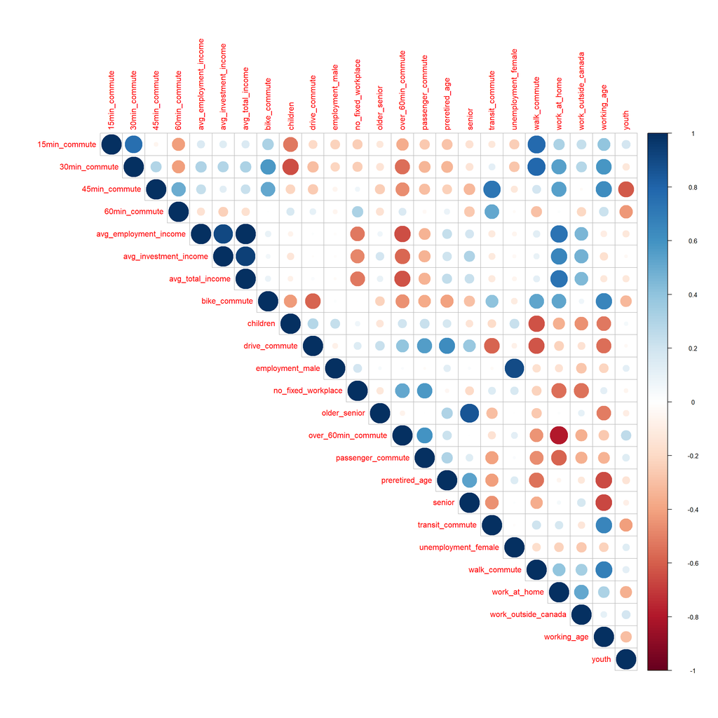

```r
neighborhoods %>%
  cor() %>%
  corrplot(type = 'upper', order = 'alphabet')
```

### PCA Results

```r
neighborhoods %>%
  prcomp(center = TRUE, scale. = TRUE) -> neighborhoods.pca
```

### PCA Component Selection

```r
get_eigenvalue(neighborhoods.pca)
```

```
##          eigenvalue variance.percent cumulative.variance.percent
## Dim.1  7.0752158142     2.948007e+01                    29.48007
## Dim.2  4.8313179508     2.013049e+01                    49.61056
## Dim.3  2.9842330289     1.243430e+01                    62.04486
## Dim.4  2.1205795556     8.835748e+00                    70.88061
## Dim.5  1.5707959018     6.544983e+00                    77.42559
## Dim.6  1.3332425542     5.555177e+00                    82.98077
## Dim.7  0.8632346465     3.596811e+00                    86.57758
## Dim.8  0.6741708373     2.809045e+00                    89.38663
## Dim.9  0.5028230945     2.095096e+00                    91.48172
## Dim.10 0.4496242658     1.873434e+00                    93.35516
## Dim.11 0.3891201673     1.621334e+00                    94.97649
## Dim.12 0.2595283259     1.081368e+00                    96.05786
## Dim.13 0.2425522500     1.010634e+00                    97.06849
## Dim.14 0.1570320617     6.543003e-01                    97.72279
## Dim.15 0.1286189963     5.359125e-01                    98.25871
## Dim.16 0.0901701300     3.757089e-01                    98.63441
## Dim.17 0.0815730155     3.398876e-01                    98.97430
## Dim.18 0.0774359052     3.226496e-01                    99.29695
## Dim.19 0.0623461817     2.597758e-01                    99.55673
## Dim.20 0.0557575615     2.323232e-01                    99.78905
## Dim.21 0.0492744829     2.053103e-01                    99.99436
## Dim.22 0.0010025074     4.177114e-03                    99.99854
## Dim.23 0.0001931431     8.047629e-04                    99.99934
## Dim.24 0.0001576220     6.567583e-04                   100.00000
```

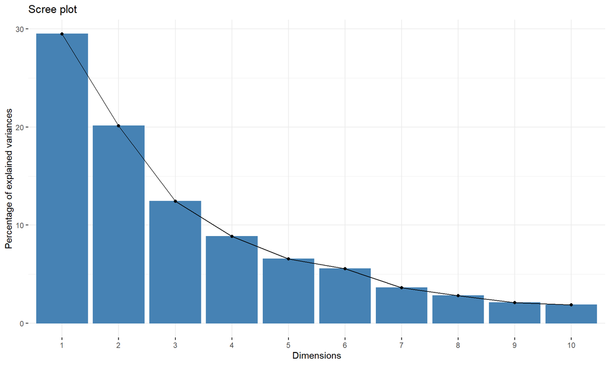

```r
fviz_eig(neighborhoods.pca)
```

```r
fa.parallel(neighborhoods, fa = "pc", plot = FALSE)
```

```
## Parallel analysis suggests that the number of factors =  NA  and the number of components =  5
```

The scree plot and eigenvalues suggest taking the first 6 principal components while the parallel analysis suggests taking the first 5 principal components.

```r
neighborhoods.pca$rotation[,1:5]
```

```
##                               PC1           PC2          PC3         PC4
## children               0.21444168 -0.0272242617 -0.191838516  0.18768913
## youth                  0.08290342 -0.0507041163  0.390041103  0.25158546
## working_age           -0.25239591  0.3113150961 -0.003275977 -0.08067178
## preretired_age         0.16564458 -0.2610643946 -0.158636631 -0.09916612
## senior                 0.09293335 -0.3272537385  0.010194224 -0.14168918
## older_senior           0.07069071 -0.2470152160  0.004040906 -0.12585750
## drive_commute          0.21762620 -0.1874190942 -0.043718023 -0.27348388
## passenger_commute      0.25695107  0.0225183418  0.088692442 -0.17771650
## transit_commute       -0.14435766  0.2814277736 -0.282562138  0.01047802
## walk_commute          -0.29154654  0.1128023447  0.273092139  0.06700118
## bike_commute          -0.25341031  0.1606452874 -0.050681456  0.04848634
## 15min_commute         -0.21788852 -0.0008798968  0.348293970 -0.03497572
## 30min_commute         -0.29903679  0.0098554636  0.191465783 -0.06323342
## 45min_commute         -0.20353069  0.1514302277 -0.377100431 -0.10638522
## 60min_commute          0.04715245  0.1756527764 -0.403223815 -0.17622810
## over_60min_commute     0.29513372  0.1320428439  0.114261842 -0.10558729
## unemployment_female    0.10805595  0.0037670989 -0.103490157  0.56625853
## employment_male        0.08778572 -0.0020496518 -0.118018121  0.57271188
## work_at_home          -0.30927565 -0.1594753822 -0.175469056 -0.04445284
## no_fixed_workplace     0.17326498  0.2513590768 -0.045558985 -0.05304772
## work_outside_canada   -0.18734848 -0.1912222190  0.129924911 -0.07840416
## avg_total_income      -0.19677019 -0.3252428850 -0.165003123  0.06944451
## avg_employment_income -0.19925452 -0.3148470662 -0.166559746  0.07546149
## avg_investment_income -0.18083287 -0.3297133403 -0.117611686  0.08394512
##                                PC5
## children              -0.387540546
## youth                 -0.258671855
## working_age            0.005960121
## preretired_age         0.097512379
## senior                 0.439829643
## older_senior           0.501451880
## drive_commute         -0.067233612
## passenger_commute      0.007273122
## transit_commute        0.042073463
## walk_commute           0.053778242
## bike_commute           0.229905217
## 15min_commute          0.042375125
## 30min_commute          0.151522769
## 45min_commute          0.057003164
## 60min_commute         -0.083127483
## over_60min_commute    -0.026700464
## unemployment_female    0.218150891
## employment_male        0.262523824
## work_at_home           0.001137302
## no_fixed_workplace     0.192534521
## work_outside_canada   -0.117477827
## avg_total_income      -0.154859934
## avg_employment_income -0.171728803
## avg_investment_income -0.099402646
```

### PC Correlations

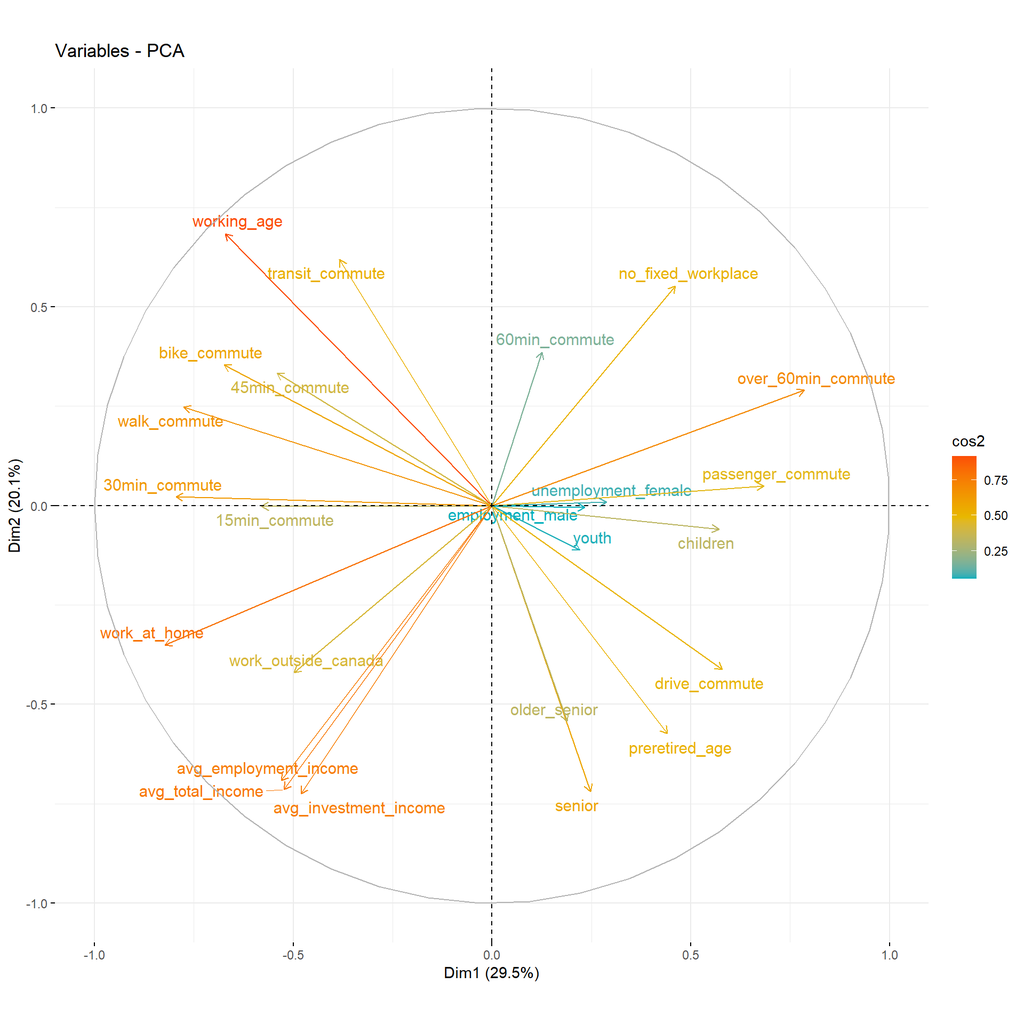

```r
fviz_pca_var(neighborhoods.pca,
             col.var = "cos2",
             gradient.cols = c("#00AFBB", "#E7B800", "#FC4E07"),
             repel = TRUE)
```

Plotting the variables with the first component against the second component shows how the variables relate to each other. The older demographic correlates negatively with short commutes, walking, biking, and transit. The longer commutes and a non-fixed workplace correlate negatively with income and working at home or outside of Canada. The employment rate for males, unemployment rates for females, youth population, and 60 minute commutes are not well-represented by the first two principal components.

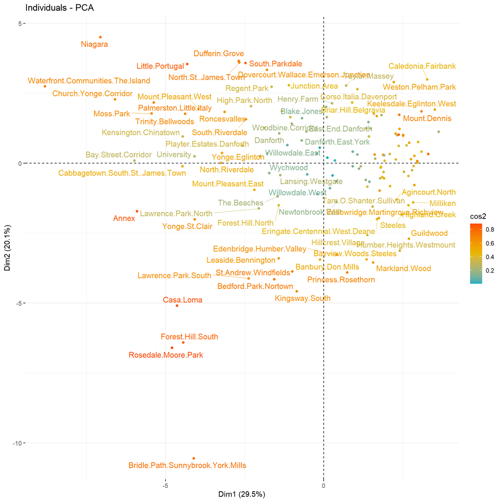

```r
fviz_pca_ind(neighborhoods.pca,
             col.ind = "cos2",
             gradient.cols = c("#00AFBB", "#E7B800", "#FC4E07"),
             repel = TRUE)
```

Casa Loma, Forest Hill South, Rosedale Moore Park, and Niagara are some neighborhoods that are distant from the large cluster of neighborhoods.